# Risk Factor Analysis

## Outcome Variable

**Outcome Variable:** y_rate_len

## Predictor Variables

**Intervention Variable:** nhh

**Adjustment Set:**

- arm
- W_mage
- meducyrs
- feducyrs
- W_mhtcm
- W_mwtkg
- W_mbmi
- W_nrooms
- trth2o
- cleanck
- impfloor
- impsan
- safeh20
- delta_W_mage
- delta_meducyrs
- delta_feducyrs
- delta_W_mhtcm
- delta_W_mwtkg
- delta_W_mbmi
- delta_W_nrooms
- delta_trth2o
- delta_cleanck
- delta_impfloor
- delta_impsan
- delta_safeh20

## Stratifying Variables

The analysis was stratified on these variable(s):

- agecat
- studyid
- country

## Data Summary

| agecat | studyid | country | nhh | n_cell | n | outcome_variable |
| --- | --- | --- | --- | --- | --- | --- |
| 0-3 months | ki1000108-IRC | INDIA | 3 or less | 53 | 377 | y_rate_len |
| 0-3 months | ki1000108-IRC | INDIA | 4-5 | 146 | 377 | y_rate_len |
| 0-3 months | ki1000108-IRC | INDIA | 6-7 | 99 | 377 | y_rate_len |
| 0-3 months | ki1000108-IRC | INDIA | 8+ | 79 | 377 | y_rate_len |
| 0-3 months | ki1017093-NIH-Birth | BANGLADESH | 3 or less | 101 | 566 | y_rate_len |
| 0-3 months | ki1017093-NIH-Birth | BANGLADESH | 4-5 | 239 | 566 | y_rate_len |
| 0-3 months | ki1017093-NIH-Birth | BANGLADESH | 6-7 | 132 | 566 | y_rate_len |
| 0-3 months | ki1017093-NIH-Birth | BANGLADESH | 8+ | 94 | 566 | y_rate_len |
| 0-3 months | ki1017093b-PROVIDE | BANGLADESH | 3 or less | 123 | 640 | y_rate_len |
| 0-3 months | ki1017093b-PROVIDE | BANGLADESH | 4-5 | 296 | 640 | y_rate_len |
| 0-3 months | ki1017093b-PROVIDE | BANGLADESH | 6-7 | 136 | 640 | y_rate_len |
| 0-3 months | ki1017093b-PROVIDE | BANGLADESH | 8+ | 85 | 640 | y_rate_len |
| 0-3 months | ki1017093c-NIH-Crypto | BANGLADESH | 3 or less | 108 | 721 | y_rate_len |
| 0-3 months | ki1017093c-NIH-Crypto | BANGLADESH | 4-5 | 324 | 721 | y_rate_len |
| 0-3 months | ki1017093c-NIH-Crypto | BANGLADESH | 6-7 | 169 | 721 | y_rate_len |
| 0-3 months | ki1017093c-NIH-Crypto | BANGLADESH | 8+ | 120 | 721 | y_rate_len |
| 3-6 months | ki1000108-IRC | INDIA | 3 or less | 57 | 397 | y_rate_len |
| 3-6 months | ki1000108-IRC | INDIA | 4-5 | 154 | 397 | y_rate_len |
| 3-6 months | ki1000108-IRC | INDIA | 6-7 | 103 | 397 | y_rate_len |
| 3-6 months | ki1000108-IRC | INDIA | 8+ | 83 | 397 | y_rate_len |
| 3-6 months | ki1017093-NIH-Birth | BANGLADESH | 3 or less | 89 | 523 | y_rate_len |
| 3-6 months | ki1017093-NIH-Birth | BANGLADESH | 4-5 | 223 | 523 | y_rate_len |
| 3-6 months | ki1017093-NIH-Birth | BANGLADESH | 6-7 | 126 | 523 | y_rate_len |
| 3-6 months | ki1017093-NIH-Birth | BANGLADESH | 8+ | 85 | 523 | y_rate_len |
| 3-6 months | ki1017093b-PROVIDE | BANGLADESH | 3 or less | 104 | 598 | y_rate_len |
| 3-6 months | ki1017093b-PROVIDE | BANGLADESH | 4-5 | 285 | 598 | y_rate_len |
| 3-6 months | ki1017093b-PROVIDE | BANGLADESH | 6-7 | 129 | 598 | y_rate_len |
| 3-6 months | ki1017093b-PROVIDE | BANGLADESH | 8+ | 80 | 598 | y_rate_len |
| 3-6 months | ki1017093c-NIH-Crypto | BANGLADESH | 3 or less | 101 | 695 | y_rate_len |
| 3-6 months | ki1017093c-NIH-Crypto | BANGLADESH | 4-5 | 316 | 695 | y_rate_len |

[output cut: 138 more lines]

The following strata were considered:

- agecat: 0-3 months, studyid: ki1000108-IRC, country: INDIA
- agecat: 0-3 months, studyid: ki1017093-NIH-Birth, country: BANGLADESH
- agecat: 0-3 months, studyid: ki1017093b-PROVIDE, country: BANGLADESH
- agecat: 0-3 months, studyid: ki1017093c-NIH-Crypto, country: BANGLADESH
- agecat: 12-15 months, studyid: ki1000108-IRC, country: INDIA
- agecat: 12-15 months, studyid: ki1000304b-SAS-FoodSuppl, country: INDIA
- agecat: 12-15 months, studyid: ki1017093-NIH-Birth, country: BANGLADESH
- agecat: 12-15 months, studyid: ki1017093b-PROVIDE, country: BANGLADESH
- agecat: 12-15 months, studyid: ki1017093c-NIH-Crypto, country: BANGLADESH
- agecat: 12-15 months, studyid: ki1148112-LCNI-5, country: MALAWI
- agecat: 15-18 months, studyid: ki1000108-IRC, country: INDIA
- agecat: 15-18 months, studyid: ki1000304b-SAS-FoodSuppl, country: INDIA
- agecat: 15-18 months, studyid: ki1017093-NIH-Birth, country: BANGLADESH
- agecat: 15-18 months, studyid: ki1017093b-PROVIDE, country: BANGLADESH
- agecat: 15-18 months, studyid: ki1017093c-NIH-Crypto, country: BANGLADESH
- agecat: 15-18 months, studyid: ki1148112-LCNI-5, country: MALAWI
- agecat: 18-21 months, studyid: ki1000108-IRC, country: INDIA
- agecat: 18-21 months, studyid: ki1017093-NIH-Birth, country: BANGLADESH
- agecat: 18-21 months, studyid: ki1017093b-PROVIDE, country: BANGLADESH
- agecat: 18-21 months, studyid: ki1017093c-NIH-Crypto, country: BANGLADESH
- agecat: 18-21 months, studyid: ki1148112-LCNI-5, country: MALAWI
- agecat: 21-24 months, studyid: ki1000108-IRC, country: INDIA
- agecat: 21-24 months, studyid: ki1017093-NIH-Birth, country: BANGLADESH
- agecat: 21-24 months, studyid: ki1017093b-PROVIDE, country: BANGLADESH
- agecat: 21-24 months, studyid: ki1017093c-NIH-Crypto, country: BANGLADESH
- agecat: 21-24 months, studyid: ki1148112-LCNI-5, country: MALAWI
- agecat: 3-6 months, studyid: ki1000108-IRC, country: INDIA
- agecat: 3-6 months, studyid: ki1017093-NIH-Birth, country: BANGLADESH
- agecat: 3-6 months, studyid: ki1017093b-PROVIDE, country: BANGLADESH
- agecat: 3-6 months, studyid: ki1017093c-NIH-Crypto, country: BANGLADESH
- agecat: 6-9 months, studyid: ki1000108-IRC, country: INDIA
- agecat: 6-9 months, studyid: ki1000304b-SAS-FoodSuppl, country: INDIA
- agecat: 6-9 months, studyid: ki1017093-NIH-Birth, country: BANGLADESH
- agecat: 6-9 months, studyid: ki1017093b-PROVIDE, country: BANGLADESH
- agecat: 6-9 months, studyid: ki1017093c-NIH-Crypto, country: BANGLADESH
- agecat: 6-9 months, studyid: ki1148112-LCNI-5, country: MALAWI
- agecat: 9-12 months, studyid: ki1000108-IRC, country: INDIA
- agecat: 9-12 months, studyid: ki1000304b-SAS-FoodSuppl, country: INDIA
- agecat: 9-12 months, studyid: ki1017093-NIH-Birth, country: BANGLADESH
- agecat: 9-12 months, studyid: ki1017093b-PROVIDE, country: BANGLADESH
- agecat: 9-12 months, studyid: ki1017093c-NIH-Crypto, country: BANGLADESH
- agecat: 9-12 months, studyid: ki1148112-LCNI-5, country: MALAWI

## Methods Detail

We’re interested in the causal parameters $E[Y_a]$ for all values of $a \in \mathcal{A}$. These parameters represent the mean outcome if, possibly contrary to fact, we intervened to set all units to have $A=a$. Under the randomization and positivity assumptions, these are identified by the statistical parameters $\psi_a=E_W[E_{Y|A,W}(Y|A=a,W)]$. In addition, we’re interested in the mean of $Y$, $E[Y]$ under no intervention (the observed mean). We will estimate these parameters by using SuperLearner to fit the relevant likelihood factors – $E_{Y|A,W}(Y|A=a,W)$ and $p(A=a|W)$, and then updating our likelihood fit using a joint TMLE.

For unadjusted analyses ($W=\{\}$), initial likelihoods were estimated using Lrnr_glm to estimate the simple $E(Y|A)$ and Lrnr_mean to estimate $p(A)$. For adjusted analyses, a small library containing Lrnr_glmnet, Lrnr_xgboost, and Lrnr_mean was used.

Having estimated these parameters, we will then use the delta method to estimate relative risks and attributable risks relative to a prespecified baseline level of $A$.

# Results Detail

## Results Plots

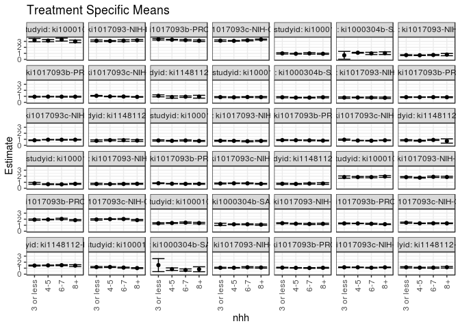

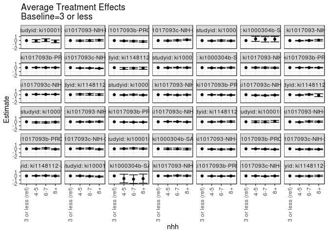

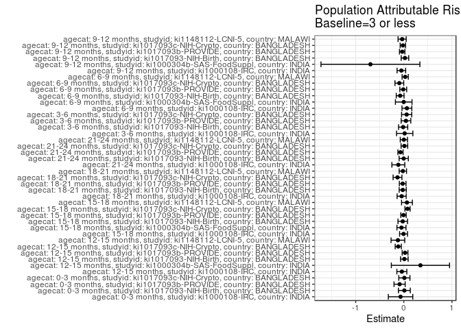

## Results Table

### Parameter: TSM

| agecat | studyid | country | intervention_level | baseline_level | estimate | ci_lower | ci_upper |
| --- | --- | --- | --- | --- | --- | --- | --- |
| 0-3 months | ki1000108-IRC | INDIA | 3 or less | NA | 3.2061413 | 2.9348692 | 3.4774134 |
| 0-3 months | ki1000108-IRC | INDIA | 4-5 | NA | 3.1228589 | 2.9431306 | 3.3025873 |
| 0-3 months | ki1000108-IRC | INDIA | 6-7 | NA | 3.2922738 | 3.0514851 | 3.5330625 |
| 0-3 months | ki1000108-IRC | INDIA | 8+ | NA | 2.9962957 | 2.7795238 | 3.2130676 |
| 0-3 months | ki1017093-NIH-Birth | BANGLADESH | 3 or less | NA | 3.0990292 | 2.9653424 | 3.2327160 |
| 0-3 months | ki1017093-NIH-Birth | BANGLADESH | 4-5 | NA | 3.0612945 | 2.9816262 | 3.1409629 |
| 0-3 months | ki1017093-NIH-Birth | BANGLADESH | 6-7 | NA | 3.1065206 | 2.9618482 | 3.2511929 |
| 0-3 months | ki1017093-NIH-Birth | BANGLADESH | 8+ | NA | 3.1751226 | 3.0339385 | 3.3163068 |
| 0-3 months | ki1017093b-PROVIDE | BANGLADESH | 3 or less | NA | 3.3453489 | 3.2214600 | 3.4692378 |
| 0-3 months | ki1017093b-PROVIDE | BANGLADESH | 4-5 | NA | 3.2705732 | 3.2088210 | 3.3323255 |
| 0-3 months | ki1017093b-PROVIDE | BANGLADESH | 6-7 | NA | 3.1993420 | 3.0847144 | 3.3139696 |
| 0-3 months | ki1017093b-PROVIDE | BANGLADESH | 8+ | NA | 3.1043804 | 2.9767652 | 3.2319956 |
| 0-3 months | ki1017093c-NIH-Crypto | BANGLADESH | 3 or less | NA | 3.1178509 | 2.9950244 | 3.2406774 |
| 0-3 months | ki1017093c-NIH-Crypto | BANGLADESH | 4-5 | NA | 3.0840968 | 3.0244850 | 3.1437086 |
| 0-3 months | ki1017093c-NIH-Crypto | BANGLADESH | 6-7 | NA | 3.1758538 | 3.0801607 | 3.2715468 |
| 0-3 months | ki1017093c-NIH-Crypto | BANGLADESH | 8+ | NA | 3.3064299 | 3.2231899 | 3.3896700 |
| 3-6 months | ki1000108-IRC | INDIA | 3 or less | NA | 1.8623588 | 1.6788576 | 2.0458600 |
| 3-6 months | ki1000108-IRC | INDIA | 4-5 | NA | 1.8559730 | 1.7496569 | 1.9622891 |
| 3-6 months | ki1000108-IRC | INDIA | 6-7 | NA | 1.8551400 | 1.7413100 | 1.9689701 |
| 3-6 months | ki1000108-IRC | INDIA | 8+ | NA | 1.9594751 | 1.8127315 | 2.1062186 |
| 3-6 months | ki1017093-NIH-Birth | BANGLADESH | 3 or less | NA | 1.8467759 | 1.7470329 | 1.9465190 |
| 3-6 months | ki1017093-NIH-Birth | BANGLADESH | 4-5 | NA | 1.7658544 | 1.6906047 | 1.8411041 |
| 3-6 months | ki1017093-NIH-Birth | BANGLADESH | 6-7 | NA | 1.9054455 | 1.7974035 | 2.0134875 |
| 3-6 months | ki1017093-NIH-Birth | BANGLADESH | 8+ | NA | 1.8661699 | 1.7394016 | 1.9929382 |
| 3-6 months | ki1017093b-PROVIDE | BANGLADESH | 3 or less | NA | 1.9209837 | 1.8134407 | 2.0285267 |
| 3-6 months | ki1017093b-PROVIDE | BANGLADESH | 4-5 | NA | 1.9476414 | 1.8947457 | 2.0005371 |
| 3-6 months | ki1017093b-PROVIDE | BANGLADESH | 6-7 | NA | 2.0426436 | 1.9242254 | 2.1610619 |
| 3-6 months | ki1017093b-PROVIDE | BANGLADESH | 8+ | NA | 1.8400229 | 1.7472793 | 1.9327666 |
| 3-6 months | ki1017093c-NIH-Crypto | BANGLADESH | 3 or less | NA | 1.9468256 | 1.8382874 | 2.0553639 |
| 3-6 months | ki1017093c-NIH-Crypto | BANGLADESH | 4-5 | NA | 2.0132007 | 1.9543551 | 2.0720462 |

[output cut: 138 more lines]

### Parameter: E(Y)

| agecat | studyid | country | intervention_level | baseline_level | estimate | ci_lower | ci_upper |
| --- | --- | --- | --- | --- | --- | --- | --- |
| 0-3 months | ki1000108-IRC | INDIA | NA | NA | 3.1382493 | 3.0275242 | 3.2489743 |
| 0-3 months | ki1017093-NIH-Birth | BANGLADESH | NA | NA | 3.1100116 | 3.0566021 | 3.1634210 |
| 0-3 months | ki1017093b-PROVIDE | BANGLADESH | NA | NA | 3.2576810 | 3.2206777 | 3.2946843 |
| 0-3 months | ki1017093c-NIH-Crypto | BANGLADESH | NA | NA | 3.1292449 | 3.0928504 | 3.1656393 |
| 3-6 months | ki1000108-IRC | INDIA | NA | NA | 1.8806738 | 1.8168757 | 1.9444719 |
| 3-6 months | ki1017093-NIH-Birth | BANGLADESH | NA | NA | 1.8326915 | 1.7846731 | 1.8807099 |
| 3-6 months | ki1017093b-PROVIDE | BANGLADESH | NA | NA | 1.9657457 | 1.9318660 | 1.9996254 |
| 3-6 months | ki1017093c-NIH-Crypto | BANGLADESH | NA | NA | 2.0057973 | 1.9693775 | 2.0422170 |
| 6-9 months | ki1000108-IRC | INDIA | NA | NA | 1.3724009 | 1.3237927 | 1.4210091 |
| 6-9 months | ki1000304b-SAS-FoodSuppl | INDIA | NA | NA | 1.1426155 | 1.1021386 | 1.1830923 |
| 6-9 months | ki1017093-NIH-Birth | BANGLADESH | NA | NA | 1.2555950 | 1.2150667 | 1.2961234 |
| 6-9 months | ki1017093b-PROVIDE | BANGLADESH | NA | NA | 1.2824185 | 1.2571827 | 1.3076542 |
| 6-9 months | ki1017093c-NIH-Crypto | BANGLADESH | NA | NA | 1.3282695 | 1.2988292 | 1.3577098 |
| 6-9 months | ki1148112-LCNI-5 | MALAWI | NA | NA | 1.4589363 | 1.4224162 | 1.4954563 |
| 9-12 months | ki1000108-IRC | INDIA | NA | NA | 1.1234734 | 1.0841051 | 1.1628417 |
| 9-12 months | ki1000304b-SAS-FoodSuppl | INDIA | NA | NA | 0.8106649 | 0.6745544 | 0.9467754 |
| 9-12 months | ki1017093-NIH-Birth | BANGLADESH | NA | NA | 1.0885809 | 1.0534446 | 1.1237171 |
| 9-12 months | ki1017093b-PROVIDE | BANGLADESH | NA | NA | 1.0499750 | 1.0230130 | 1.0769370 |
| 9-12 months | ki1017093c-NIH-Crypto | BANGLADESH | NA | NA | 1.1234745 | 1.0972274 | 1.1497215 |
| 9-12 months | ki1148112-LCNI-5 | MALAWI | NA | NA | 1.1007887 | 1.0539615 | 1.1476158 |
| 12-15 months | ki1000108-IRC | INDIA | NA | NA | 0.9553539 | 0.9137750 | 0.9969329 |
| 12-15 months | ki1000304b-SAS-FoodSuppl | INDIA | NA | NA | 1.0267825 | 0.9374856 | 1.1160794 |
| 12-15 months | ki1017093-NIH-Birth | BANGLADESH | NA | NA | 0.7241623 | 0.6797013 | 0.7686233 |
| 12-15 months | ki1017093b-PROVIDE | BANGLADESH | NA | NA | 0.9597501 | 0.9335899 | 0.9859102 |
| 12-15 months | ki1017093c-NIH-Crypto | BANGLADESH | NA | NA | 0.9711395 | 0.9465805 | 0.9956985 |
| 12-15 months | ki1148112-LCNI-5 | MALAWI | NA | NA | 0.9578403 | 0.8612449 | 1.0544357 |
| 15-18 months | ki1000108-IRC | INDIA | NA | NA | 0.8591216 | 0.8197594 | 0.8984837 |
| 15-18 months | ki1000304b-SAS-FoodSuppl | INDIA | NA | NA | 0.7947861 | 0.7590601 | 0.8305122 |
| 15-18 months | ki1017093-NIH-Birth | BANGLADESH | NA | NA | 0.7727719 | 0.7325606 | 0.8129832 |
| 15-18 months | ki1017093b-PROVIDE | BANGLADESH | NA | NA | 0.8560998 | 0.8320145 | 0.8801852 |
| 15-18 months | ki1017093c-NIH-Crypto | BANGLADESH | NA | NA | 0.9177168 | 0.8947657 | 0.9406678 |
| 15-18 months | ki1148112-LCNI-5 | MALAWI | NA | NA | 0.8227868 | 0.7513696 | 0.8942040 |
| 18-21 months | ki1000108-IRC | INDIA | NA | NA | 0.7598022 | 0.7214752 | 0.7981291 |
| 18-21 months | ki1017093-NIH-Birth | BANGLADESH | NA | NA | 0.7291468 | 0.6930874 | 0.7652062 |
| 18-21 months | ki1017093b-PROVIDE | BANGLADESH | NA | NA | 0.8393377 | 0.8153485 | 0.8633269 |
| 18-21 months | ki1017093c-NIH-Crypto | BANGLADESH | NA | NA | 0.7977755 | 0.7744353 | 0.8211158 |
| 18-21 months | ki1148112-LCNI-5 | MALAWI | NA | NA | 0.8198090 | 0.7732927 | 0.8663254 |
| 21-24 months | ki1000108-IRC | INDIA | NA | NA | 0.7084129 | 0.6674749 | 0.7493508 |
| 21-24 months | ki1017093-NIH-Birth | BANGLADESH | NA | NA | 0.7172178 | 0.6817161 | 0.7527194 |
| 21-24 months | ki1017093b-PROVIDE | BANGLADESH | NA | NA | 0.7631391 | 0.7377453 | 0.7885328 |
| 21-24 months | ki1017093c-NIH-Crypto | BANGLADESH | NA | NA | 0.7993353 | 0.7748026 | 0.8238681 |
| 21-24 months | ki1148112-LCNI-5 | MALAWI | NA | NA | 0.7505036 | 0.7048983 | 0.7961088 |

### Parameter: ATE

| agecat | studyid | country | intervention_level | baseline_level | estimate | ci_lower | ci_upper |
| --- | --- | --- | --- | --- | --- | --- | --- |
| 0-3 months | ki1000108-IRC | INDIA | 3 or less | 3 or less | 0.0000000 | 0.0000000 | 0.0000000 |
| 0-3 months | ki1000108-IRC | INDIA | 4-5 | 3 or less | -0.0832824 | -0.4081053 | 0.2415405 |
| 0-3 months | ki1000108-IRC | INDIA | 6-7 | 3 or less | 0.0861325 | -0.2759915 | 0.4482565 |
| 0-3 months | ki1000108-IRC | INDIA | 8+ | 3 or less | -0.2098456 | -0.5578295 | 0.1381383 |
| 0-3 months | ki1017093-NIH-Birth | BANGLADESH | 3 or less | 3 or less | 0.0000000 | 0.0000000 | 0.0000000 |
| 0-3 months | ki1017093-NIH-Birth | BANGLADESH | 4-5 | 3 or less | -0.0377347 | -0.1936753 | 0.1182060 |
| 0-3 months | ki1017093-NIH-Birth | BANGLADESH | 6-7 | 3 or less | 0.0074914 | -0.1894848 | 0.2044675 |
| 0-3 months | ki1017093-NIH-Birth | BANGLADESH | 8+ | 3 or less | 0.0760934 | -0.1184205 | 0.2706074 |
| 0-3 months | ki1017093b-PROVIDE | BANGLADESH | 3 or less | 3 or less | 0.0000000 | 0.0000000 | 0.0000000 |
| 0-3 months | ki1017093b-PROVIDE | BANGLADESH | 4-5 | 3 or less | -0.0747756 | -0.2131438 | 0.0635926 |
| 0-3 months | ki1017093b-PROVIDE | BANGLADESH | 6-7 | 3 or less | -0.1460069 | -0.3148530 | 0.0228392 |
| 0-3 months | ki1017093b-PROVIDE | BANGLADESH | 8+ | 3 or less | -0.2409685 | -0.4187299 | -0.0632071 |
| 0-3 months | ki1017093c-NIH-Crypto | BANGLADESH | 3 or less | 3 or less | 0.0000000 | 0.0000000 | 0.0000000 |
| 0-3 months | ki1017093c-NIH-Crypto | BANGLADESH | 4-5 | 3 or less | -0.0337541 | -0.1703784 | 0.1028702 |
| 0-3 months | ki1017093c-NIH-Crypto | BANGLADESH | 6-7 | 3 or less | 0.0580028 | -0.0978130 | 0.2138186 |
| 0-3 months | ki1017093c-NIH-Crypto | BANGLADESH | 8+ | 3 or less | 0.1885790 | 0.0396891 | 0.3374689 |
| 3-6 months | ki1000108-IRC | INDIA | 3 or less | 3 or less | 0.0000000 | 0.0000000 | 0.0000000 |
| 3-6 months | ki1000108-IRC | INDIA | 4-5 | 3 or less | -0.0063858 | -0.2189205 | 0.2061489 |
| 3-6 months | ki1000108-IRC | INDIA | 6-7 | 3 or less | -0.0072188 | -0.2239011 | 0.2094635 |
| 3-6 months | ki1000108-IRC | INDIA | 8+ | 3 or less | 0.0971163 | -0.1381315 | 0.3323641 |
| 3-6 months | ki1017093-NIH-Birth | BANGLADESH | 3 or less | 3 or less | 0.0000000 | 0.0000000 | 0.0000000 |
| 3-6 months | ki1017093-NIH-Birth | BANGLADESH | 4-5 | 3 or less | -0.0809215 | -0.2059379 | 0.0440949 |
| 3-6 months | ki1017093-NIH-Birth | BANGLADESH | 6-7 | 3 or less | 0.0586696 | -0.0883727 | 0.2057119 |
| 3-6 months | ki1017093-NIH-Birth | BANGLADESH | 8+ | 3 or less | 0.0193939 | -0.1419181 | 0.1807060 |
| 3-6 months | ki1017093b-PROVIDE | BANGLADESH | 3 or less | 3 or less | 0.0000000 | 0.0000000 | 0.0000000 |
| 3-6 months | ki1017093b-PROVIDE | BANGLADESH | 4-5 | 3 or less | 0.0266577 | -0.0933754 | 0.1466907 |
| 3-6 months | ki1017093b-PROVIDE | BANGLADESH | 6-7 | 3 or less | 0.1216599 | -0.0385238 | 0.2818437 |
| 3-6 months | ki1017093b-PROVIDE | BANGLADESH | 8+ | 3 or less | -0.0809608 | -0.2230919 | 0.0611704 |
| 3-6 months | ki1017093c-NIH-Crypto | BANGLADESH | 3 or less | 3 or less | 0.0000000 | 0.0000000 | 0.0000000 |
| 3-6 months | ki1017093c-NIH-Crypto | BANGLADESH | 4-5 | 3 or less | 0.0663750 | -0.0572890 | 0.1900391 |

[output cut: 138 more lines]

### Parameter: PAR

| agecat | studyid | country | intervention_level | baseline_level | estimate | ci_lower | ci_upper |
| --- | --- | --- | --- | --- | --- | --- | --- |
| 0-3 months | ki1000108-IRC | INDIA | 3 or less | NA | -0.0678920 | -0.3222454 | 0.1864613 |
| 0-3 months | ki1017093-NIH-Birth | BANGLADESH | 3 or less | NA | 0.0109824 | -0.1123869 | 0.1343517 |
| 0-3 months | ki1017093b-PROVIDE | BANGLADESH | 3 or less | NA | -0.0876679 | -0.2035938 | 0.0282580 |
| 0-3 months | ki1017093c-NIH-Crypto | BANGLADESH | 3 or less | NA | 0.0113939 | -0.1045537 | 0.1273416 |
| 3-6 months | ki1000108-IRC | INDIA | 3 or less | NA | 0.0183150 | -0.1511860 | 0.1878160 |
| 3-6 months | ki1017093-NIH-Birth | BANGLADESH | 3 or less | NA | -0.0140845 | -0.1092960 | 0.0811271 |
| 3-6 months | ki1017093b-PROVIDE | BANGLADESH | 3 or less | NA | 0.0447620 | -0.0550906 | 0.1446146 |
| 3-6 months | ki1017093c-NIH-Crypto | BANGLADESH | 3 or less | NA | 0.0589716 | -0.0465320 | 0.1644753 |
| 6-9 months | ki1000108-IRC | INDIA | 3 or less | NA | 0.0639929 | -0.0383923 | 0.1663781 |
| 6-9 months | ki1000304b-SAS-FoodSuppl | INDIA | 3 or less | NA | -0.0022660 | -0.1746942 | 0.1701622 |
| 6-9 months | ki1017093-NIH-Birth | BANGLADESH | 3 or less | NA | -0.0763556 | -0.1573525 | 0.0046412 |
| 6-9 months | ki1017093b-PROVIDE | BANGLADESH | 3 or less | NA | -0.0118952 | -0.0830181 | 0.0592277 |
| 6-9 months | ki1017093c-NIH-Crypto | BANGLADESH | 3 or less | NA | -0.0933453 | -0.1842483 | -0.0024422 |
| 6-9 months | ki1148112-LCNI-5 | MALAWI | 3 or less | NA | 0.0285347 | -0.0353770 | 0.0924465 |
| 9-12 months | ki1000108-IRC | INDIA | 3 or less | NA | -0.0511263 | -0.1405639 | 0.0383112 |
| 9-12 months | ki1000304b-SAS-FoodSuppl | INDIA | 3 or less | NA | -0.6936898 | -1.7214345 | 0.3340549 |
| 9-12 months | ki1017093-NIH-Birth | BANGLADESH | 3 or less | NA | 0.0233987 | -0.0548534 | 0.1016509 |
| 9-12 months | ki1017093b-PROVIDE | BANGLADESH | 3 or less | NA | -0.0340141 | -0.0904706 | 0.0224424 |
| 9-12 months | ki1017093c-NIH-Crypto | BANGLADESH | 3 or less | NA | -0.0198347 | -0.0758349 | 0.0361655 |
| 9-12 months | ki1148112-LCNI-5 | MALAWI | 3 or less | NA | -0.0350952 | -0.1194023 | 0.0492119 |
| 12-15 months | ki1000108-IRC | INDIA | 3 or less | NA | -0.0412734 | -0.1445188 | 0.0619721 |
| 12-15 months | ki1000304b-SAS-FoodSuppl | INDIA | 3 or less | NA | 0.3454836 | -0.2594851 | 0.9504523 |
| 12-15 months | ki1017093-NIH-Birth | BANGLADESH | 3 or less | NA | 0.0110391 | -0.0674310 | 0.0895091 |
| 12-15 months | ki1017093b-PROVIDE | BANGLADESH | 3 or less | NA | 0.0256414 | -0.0341601 | 0.0854429 |
| 12-15 months | ki1017093c-NIH-Crypto | BANGLADESH | 3 or less | NA | -0.1156565 | -0.1794240 | -0.0518890 |
| 12-15 months | ki1148112-LCNI-5 | MALAWI | 3 or less | NA | -0.1230540 | -0.2652997 | 0.0191916 |
| 15-18 months | ki1000108-IRC | INDIA | 3 or less | NA | -0.0059235 | -0.0880991 | 0.0762520 |
| 15-18 months | ki1000304b-SAS-FoodSuppl | INDIA | 3 or less | NA | -0.0491715 | -0.1432636 | 0.0449207 |
| 15-18 months | ki1017093-NIH-Birth | BANGLADESH | 3 or less | NA | -0.0223121 | -0.1216301 | 0.0770059 |
| 15-18 months | ki1017093b-PROVIDE | BANGLADESH | 3 or less | NA | -0.0066570 | -0.0625345 | 0.0492205 |
| 15-18 months | ki1017093c-NIH-Crypto | BANGLADESH | 3 or less | NA | 0.0772170 | 0.0237828 | 0.1306511 |
| 15-18 months | ki1148112-LCNI-5 | MALAWI | 3 or less | NA | 0.0650540 | -0.0474351 | 0.1775432 |
| 18-21 months | ki1000108-IRC | INDIA | 3 or less | NA | -0.0452330 | -0.1396153 | 0.0491492 |
| 18-21 months | ki1017093-NIH-Birth | BANGLADESH | 3 or less | NA | -0.0227999 | -0.0963818 | 0.0507819 |
| 18-21 months | ki1017093b-PROVIDE | BANGLADESH | 3 or less | NA | -0.0239416 | -0.0928939 | 0.0450108 |
| 18-21 months | ki1017093c-NIH-Crypto | BANGLADESH | 3 or less | NA | -0.1312938 | -0.2231640 | -0.0394236 |
| 18-21 months | ki1148112-LCNI-5 | MALAWI | 3 or less | NA | -0.0204843 | -0.0969780 | 0.0560094 |
| 21-24 months | ki1000108-IRC | INDIA | 3 or less | NA | -0.1140314 | -0.2482986 | 0.0202357 |
| 21-24 months | ki1017093-NIH-Birth | BANGLADESH | 3 or less | NA | -0.0023914 | -0.0982567 | 0.0934739 |
| 21-24 months | ki1017093b-PROVIDE | BANGLADESH | 3 or less | NA | -0.0699160 | -0.1235911 | -0.0162408 |
| 21-24 months | ki1017093c-NIH-Crypto | BANGLADESH | 3 or less | NA | 0.0118179 | -0.0571250 | 0.0807607 |
| 21-24 months | ki1148112-LCNI-5 | MALAWI | 3 or less | NA | 0.0011134 | -0.0741599 | 0.0763866 |